# Types of Selection

Peter Ralph

2015-12-30

This document will go through several ways of implementing density-dependent population regulation.

Here’s the habitat we’ll work with. Note that units are in meters, and the resolution of the raster is 100m.

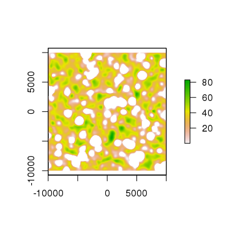

```r
pop <- make_population(
            habitat = random_habitat(),
            inaccessible.value = NA,
            uninhabitable.value = NA,
            genotypes = c("aa","aA","AA"),
            N = 0
        )
pop$N[,"aa"] <- rpois(nrow(pop$N),values(pop$habitat)[pop$accessible]/4)
pop$N[,"aA"] <- rpois(nrow(pop$N),values(pop$habitat)[pop$accessible]/2)
pop$N[,"AA"] <- rpois(nrow(pop$N),values(pop$habitat)[pop$accessible]/4)
plot(pop$habitat)
```

Here’s the basic, default demography:

```r
basic.migr <- migration(
                    kern = "gaussian",
                    sigma = 300,
                    radius = 1000,
                    normalize = 1
             )
basic.demog <- demography(
        prob.seed = 0.05,
        fecundity = 200,
        prob.germination = 0.4,
        prob.survival = 0.6,
        pollen.migration = basic.migr,
        seed.migration = basic.migr,
        genotypes = c("aa","aA","AA")
    )
```

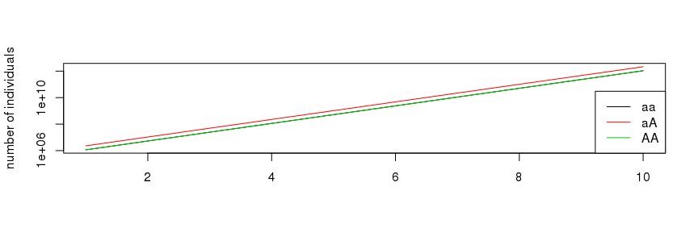

```r
demog <- setup_demography( basic.demog, pop )
sim <- simulate_pop( pop, demog, times=seq(0,10,length.out=11),
                summaries=list( totals=function(N){colSums(N)} )
            )
matplot(sim$summaries[["totals"]],type='l',lty=1, log='y',ylab='number of individuals')
legend("bottomright",lty=1,col=1:3,legend=pop$genotypes)
```

# Resource competition: available space

First, we could make the probability of germination (i.e., establishment) depend on the nearby density of individuals. Below, we set the probability of germination to $p=p_0/(1+n/K)$, where $n$ is a local average number of individuals per raster cell; this is stable if $0.05 \times 200 \times p + 0.6 = 1$, which happens if if $p=0.04$, or, with $p_0 = 0.4$, if $n=9 K$.

```r
demog <- basic.demog
demog$prob.germination <- vital(
                    function (N,...) {
                        out <- r0 / ( 1 + migrate(competition,x=rowSums(N))/K )
                        cbind( aa=out, aA=out, AA=out )
                    },
                    r0 = 0.4,
                    K = values(pop$habitat)[pop$habitable]/5,
                    competition = migration(
                                kern="gaussian",
                                sigma=200,
                                radius=400,
                                normalize=1
                        )
                )
```

This puts a contraint on the population:

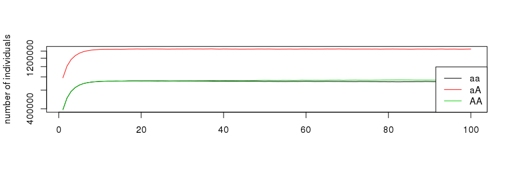

```r
demog <- setup_demography( demog, pop )
sim <- simulate_pop( pop, demog, times=seq(0,100,length.out=101),
                summaries=list( totals=function(N){colSums(N)} )
            )
matplot(sim$summaries[["totals"]],type='l',lty=1, log='y', ylab="number of individuals")
legend("bottomright",lty=1,col=1:3,legend=pop$genotypes)
```

```r
plot(sim,pop,pause=FALSE)
```

[video not shown]

# Density-dependent death rate

Now, we’ll try a different tack, making death rates depend on local densities. Since death occurs after reproduction, we need the mean number of offspring to be less than one for this to work.

```r
demog <- basic.demog
demog$prob.seed <- 0.01
demog$prob.survival <- vital(
                    function (N,...) {
                        out <- s0 / ( 1 + migrate(competition,x=rowSums(N))/K )
                        cbind( aa=out, aA=out, AA=out )
                    },
                    s0 = 0.6,
                    K = values(pop$habitat)[pop$habitable]/3,
                    competition = migration(
                                kern="gaussian",
                                sigma=200,
                                radius=400,
                                normalize=1
                        )
                )
```

Here’s what that looks like:

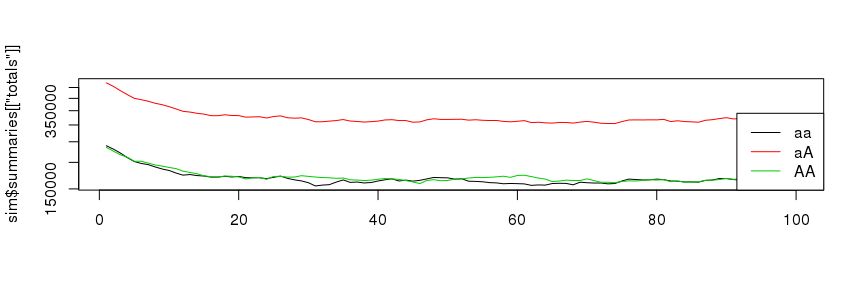

```r
demog <- setup_demography( demog, pop )
sim <- simulate_pop( pop, demog, times=seq(0,100,length.out=101),
                summaries=list( totals=function(N){colSums(N)} ) )
matplot(sim$summaries[["totals"]],type='l',lty=1, log='y')
legend("bottomright",lty=1,col=1:3,legend=pop$genotypes)
```

```r
plot(sim,pop,pause=FALSE)
```

[video not shown]